# Vinhos

FIAP-06IA - Carlos Martinelli, Jônatas Bertolazzo, Letticia Nicoli, Renato Ramos

6/18/2019

## Dataset: Qualidade do Vinho

Dataset realicionado com amostras de vinhos tintos e brancos do norte de Portugal. O objetivo é modelar a qualidade do vinho com base em testes físico-químicos.

# Ánalise Exploratória

### Amostra do dataset

```
##   fixedacidity volatileacidity citricacid residualsugar chlorides
## 1          6.6            0.24       0.35          7.70     0.031
## 2          6.7            0.34       0.43          1.60     0.041
## 3         10.6            0.31       0.49          2.20     0.063
## 4          5.4            0.18       0.24          4.80     0.041
## 5          6.7            0.30       0.44         18.75     0.057
## 6          6.8            0.50       0.11          1.50     0.075
##   freesulfurdioxide totalsulfurdioxide density   pH sulphates alcohol
## 1                36                135 0.99380 3.19      0.37    10.5
## 2                29                114 0.99014 3.23      0.44    12.6
## 3                18                 40 0.99760 3.14      0.51     9.8
## 4                30                113 0.99445 3.42      0.40     9.4
## 5                65                224 0.99956 3.11      0.53     9.1
## 6                16                 49 0.99545 3.36      0.79     9.5
##   quality Vinho
## 1       5 WHITE
## 2       6 WHITE
## 3       6   RED
## 4       6 WHITE
## 5       5 WHITE
## 6       5   RED
```

### Verifica se há preditores com variância próxima de zero

```
## integer(0)
```

Não diagnosticamos preditores que possuem um valor exclusivo (ou seja, preditores de variação zero) ou preditores que possuem poucos valores exclusivos em relação ao número de amostras.

### Verifica se há valores ausentes (NAs)

```
##       fixedacidity    volatileacidity         citricacid
##              FALSE              FALSE              FALSE
##      residualsugar          chlorides  freesulfurdioxide
##              FALSE              FALSE              FALSE
## totalsulfurdioxide            density                 pH
##              FALSE              FALSE              FALSE
##          sulphates            alcohol            quality
##              FALSE              FALSE              FALSE
##              Vinho
##              FALSE
```

Observamos que não há nenhum valor ausente/faltante nesse dataset. Dessa forma, eliminamos a necessidade de tratar esses valores.

### Resumo do dataset

```
## 'data.frame':    6497 obs. of  13 variables:
##  $ fixedacidity      : num  6.6 6.7 10.6 5.4 6.7 6.8 6.6 7.2 5.1 6.2 ...
##   ..- attr(*, "label")= chr "acidez fixa"
##  $ volatileacidity   : num  0.24 0.34 0.31 0.18 0.3 0.5 0.61 0.66 0.26 0.22 ...
##   ..- attr(*, "label")= chr "acidez volatil"
##  $ citricacid        : num  0.35 0.43 0.49 0.24 0.44 0.11 0 0.33 0.33 0.2 ...
##   ..- attr(*, "label")= chr "acido citrico"
##  $ residualsugar     : num  7.7 1.6 2.2 4.8 18.8 ...
##   ..- attr(*, "label")= chr "acucar residual"
##  $ chlorides         : num  0.031 0.041 0.063 0.041 0.057 0.075 0.069 0.068 0.027 0.035 ...
##   ..- attr(*, "label")= chr "cloretos"
##  $ freesulfurdioxide : num  36 29 18 30 65 16 4 34 46 58 ...
##   ..- attr(*, "label")= chr "dioxido de enxofre livre"
##  $ totalsulfurdioxide: num  135 114 40 113 224 49 8 102 113 184 ...
##   ..- attr(*, "label")= chr "dioxido de enxofre total"
##  $ density           : num  0.994 0.99 0.998 0.994 1 ...
##   ..- attr(*, "label")= chr "densidade"
##  $ pH                : num  3.19 3.23 3.14 3.42 3.11 3.36 3.33 3.27 3.35 3.11 ...
##   ..- attr(*, "label")= chr "pH"
##  $ sulphates         : num  0.37 0.44 0.51 0.4 0.53 0.79 0.37 0.78 0.43 0.53 ...
##   ..- attr(*, "label")= chr "sulfatos"
##  $ alcohol           : num  10.5 12.6 9.8 9.4 9.1 9.5 10.4 12.8 11.4 9 ...
##   ..- attr(*, "label")= chr "alcool"
##  $ quality           : int  5 6 6 6 5 5 4 6 7 6 ...
##   ..- attr(*, "label")= chr "qualidade"
##  $ Vinho             : Factor w/ 2 levels "RED","WHITE": 2 2 1 2 2 1 1 1 2 2 ...
##   ..- attr(*, "label")= chr "vinho"
```

O dataset possui 6497 observações de 13 variáveis. Dentre essas observações a maioria são de vinhos brancos, conforme gráfico abaixo:

```
##   fixedacidity    volatileacidity    citricacid     residualsugar
##  Min.   : 3.800   Min.   :0.0800   Min.   :0.0000   Min.   : 0.60
##  1st Qu.: 6.400   1st Qu.:0.2300   1st Qu.:0.2500   1st Qu.: 1.80
##  Median : 7.000   Median :0.2900   Median :0.3100   Median : 3.00
##  Mean   : 7.215   Mean   :0.3397   Mean   :0.3186   Mean   : 5.44
##  3rd Qu.: 7.700   3rd Qu.:0.4000   3rd Qu.:0.3900   3rd Qu.: 8.10
##  Max.   :15.900   Max.   :1.5800   Max.   :1.6600   Max.   :45.80
##    chlorides       freesulfurdioxide totalsulfurdioxide    density
##  Min.   :0.00900   Min.   :  1.00    Min.   :  6.0      Min.   :0.9871
##  1st Qu.:0.03800   1st Qu.: 17.00    1st Qu.: 77.0      1st Qu.:0.9923
##  Median :0.04700   Median : 29.00    Median :118.0      Median :0.9949
##  Mean   :0.05603   Mean   : 30.53    Mean   :115.7      Mean   :0.9947
##  3rd Qu.:0.06500   3rd Qu.: 41.00    3rd Qu.:156.0      3rd Qu.:0.9970
##  Max.   :0.61100   Max.   :289.00    Max.   :440.0      Max.   :1.0140
##        pH          sulphates         alcohol           quality
##  Min.   :2.720   Min.   :0.2200   Min.   : 0.9567   Min.   :3.000
##  1st Qu.:3.110   1st Qu.:0.4300   1st Qu.: 9.5000   1st Qu.:5.000
##  Median :3.210   Median :0.5100   Median :10.3000   Median :6.000
##  Mean   :3.219   Mean   :0.5313   Mean   :10.4862   Mean   :5.818
##  3rd Qu.:3.320   3rd Qu.:0.6000   3rd Qu.:11.3000   3rd Qu.:6.000
##  Max.   :4.010   Max.   :2.0000   Max.   :14.9000   Max.   :9.000
##    Vinho
##  RED  :1599
##  WHITE:4898
##
##
##
##
```

Observamos que as variáveis `residualsugar`, `freesulfurdioxide` e `totalsulfurdioxide` possuem valores muito distantes entre mínimo e máximo. Isso pode indicar outliers e/ou desequilíbrio entre a quantidade de vinhos tintos e brancos, o que pode interferir nos resultados de classificação.

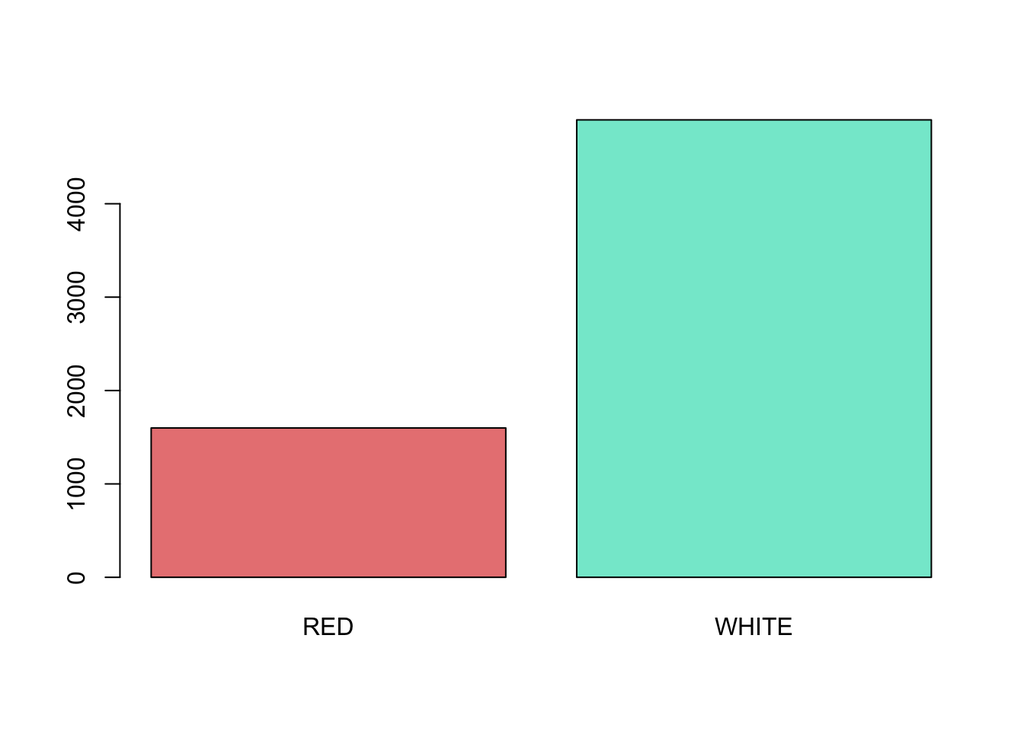

```
##        quality
## Vinho      3    4    5    6    7    8    9
##   RED     10   53  681  638  199   18    0
##   WHITE   20  163 1457 2198  880  175    5
```

Outro aspecto relevante é que a quantidade de vinhos brancos é maior do que vinhos tintos. Apenas vinhos brancos possuem a nota máxima em relação a qualidade.

### Correlação

Para realizar a correlação transformamos o campo `Vinho` (fator) para tipo numérico. Além de *normalizar* os dados para evitar algum tipo de distorção.

Todos os Vinhos

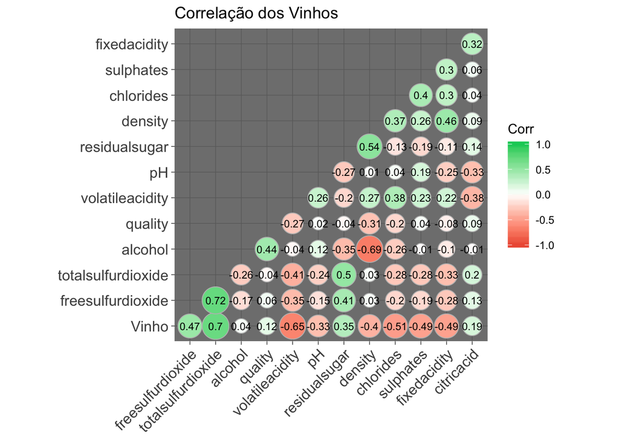

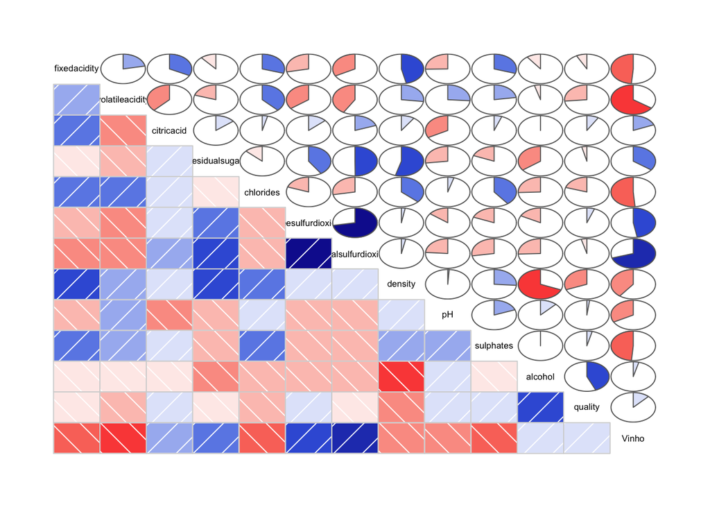

### Ánalise de outliers

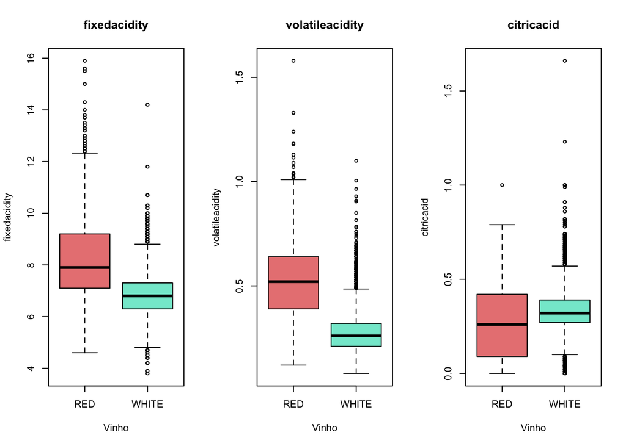

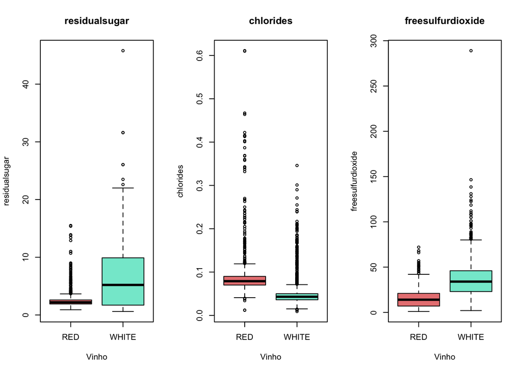

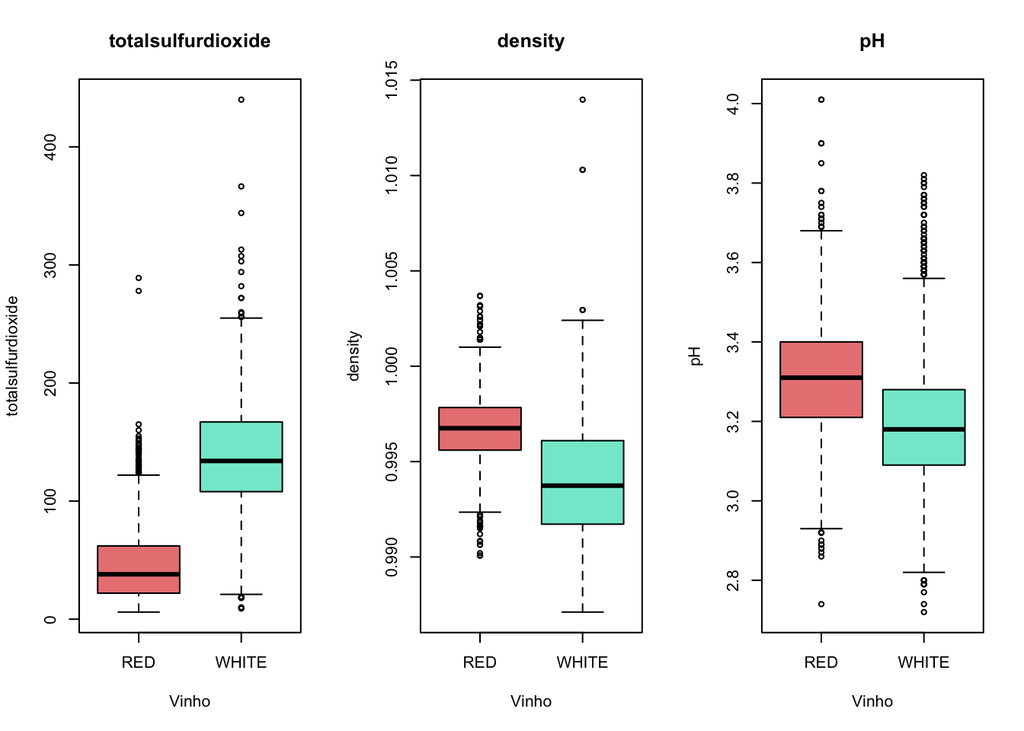

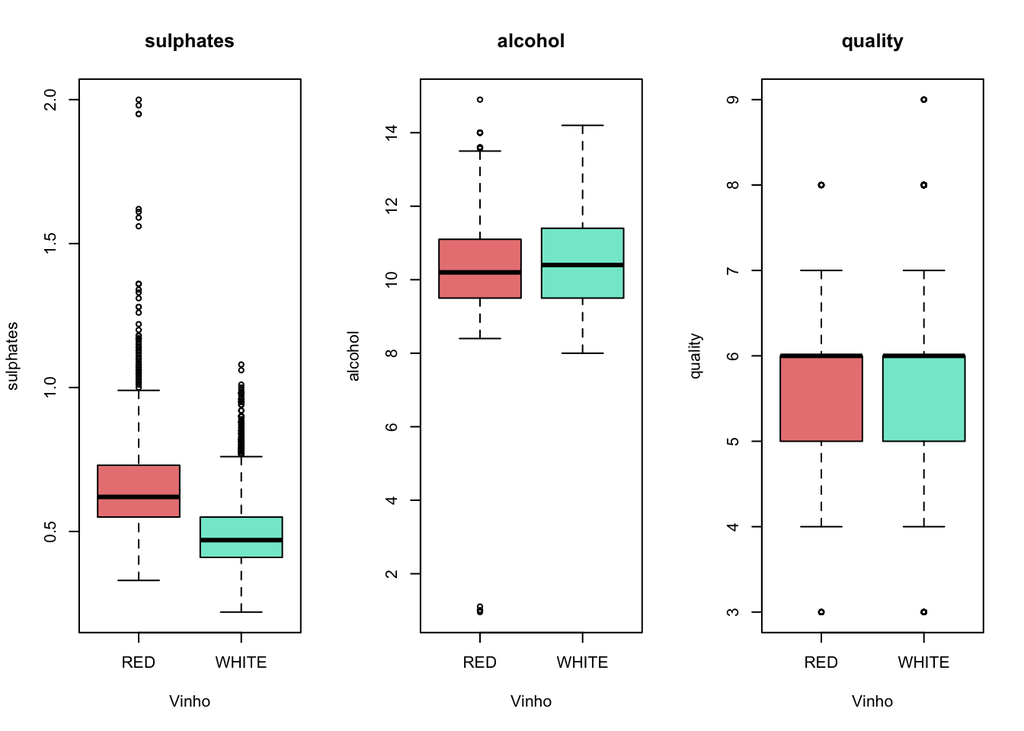

Com os gráficos acima pode-se observar que todas as variáveis possuem candidatos a outliers. No dataset existem variáveis como `residualsugar` que possui o valor máximo muito acima do terceiro quartil, isso pode gerar distorções nos algoritmos que será executado a seguir. Alem disso há uma concentração de outliears nessas variáriveis, o que traz a necessidade de remove-los.

## Explicando a variável quality

### Preparação para separação de dados: treinamento e teste

Validando a consistência de qualidade entre as bases de treino e teste

```
##
##  -3.22743853334994  -2.08229800846465 -0.937157483579359
##        0.005333333        0.033435897        0.327384615
##  0.207983041305932   1.35312356619122   2.49826409107652
##        0.438153846        0.164512821        0.030153846
##   3.64340461596181
##        0.001025641
```

```
##
##  -3.22743853334994  -2.08229800846465 -0.937157483579359
##        0.002466091        0.032675709        0.334155364
##  0.207983041305932   1.35312356619122   2.49826409107652
##        0.431565968        0.170776819        0.028360049
```

As proporções estão, consideravelemente, bem distribuídas entre a qualidade. Dessa forma, conseguimos realizar um bom treinamento para o modelo.

### Regressão Linear

No primeiro modelo mantemos todas as varáveis:

```
##
## Call:
## lm(formula = train$quality ~ train$fixedacidity + train$volatileacidity +
##     train$citricacid + train$residualsugar + train$chlorides +
##     train$freesulfurdioxide + train$totalsulfurdioxide + train$density +
##     train$pH + train$sulphates + train$alcohol + train$Vinho)
##
## Residuals:
##     Min      1Q  Median      3Q     Max
## -4.3021 -0.5342 -0.0545  0.5186  3.4175
##
## Coefficients:
##                           Estimate Std. Error t value Pr(>|t|)
## (Intercept)              -0.000516   0.012060  -0.043 0.965870
## train$fixedacidity        0.181550   0.027109   6.697 2.37e-11 ***
## train$volatileacidity    -0.278929   0.017690 -15.768  < 2e-16 ***
## train$citricacid         -0.007610   0.015400  -0.494 0.621226
## train$residualsugar       0.416013   0.037008  11.241  < 2e-16 ***
## train$chlorides          -0.029733   0.015449  -1.925 0.054343 .
## train$freesulfurdioxide   0.096713   0.017699   5.464 4.88e-08 ***
## train$totalsulfurdioxide -0.086722   0.024043  -3.607 0.000313 ***
## train$density            -0.488397   0.057445  -8.502  < 2e-16 ***
## train$pH                  0.120210   0.019309   6.226 5.20e-10 ***
## train$sulphates           0.128820   0.014939   8.623  < 2e-16 ***
## train$alcohol             0.238349   0.029200   8.163 4.14e-16 ***
## train$Vinho              -0.211672   0.032762  -6.461 1.14e-10 ***
## ---
## Signif. codes:  0 '***' 0.001 '**' 0.01 '*' 0.05 '.' 0.1 ' ' 1
##
## Residual standard error: 0.8419 on 4862 degrees of freedom
## Multiple R-squared:  0.3001, Adjusted R-squared:  0.2984
## F-statistic: 173.7 on 12 and 4862 DF,  p-value: < 2.2e-16
```

```
## Start:  AIC=-1664.7
## train$quality ~ train$fixedacidity + train$volatileacidity +
##     train$citricacid + train$residualsugar + train$chlorides +
##     train$freesulfurdioxide + train$totalsulfurdioxide + train$density +
##     train$pH + train$sulphates + train$alcohol + train$Vinho
##
##                            Df Sum of Sq    RSS     AIC
## - train$citricacid          1     0.173 3446.5 -1666.5
## <none>                                  3446.3 -1664.7
## - train$chlorides           1     2.625 3449.0 -1663.0
## - train$totalsulfurdioxide  1     9.222 3455.6 -1653.7
## - train$freesulfurdioxide   1    21.164 3467.5 -1636.8
## - train$pH                  1    27.474 3473.8 -1628.0
## - train$Vinho               1    29.589 3475.9 -1625.0
## - train$fixedacidity        1    31.791 3478.1 -1621.9
## - train$alcohol             1    47.227 3493.6 -1600.3
## - train$density             1    51.237 3497.6 -1594.8
## - train$sulphates           1    52.709 3499.0 -1592.7
## - train$residualsugar       1    89.571 3535.9 -1541.6
## - train$volatileacidity     1   176.238 3622.6 -1423.6
##
## Step:  AIC=-1666.45
## train$quality ~ train$fixedacidity + train$volatileacidity +
##     train$residualsugar + train$chlorides + train$freesulfurdioxide +
##     train$totalsulfurdioxide + train$density + train$pH + train$sulphates +
##     train$alcohol + train$Vinho
##
##                            Df Sum of Sq    RSS     AIC
## <none>                                  3446.5 -1666.5
## + train$citricacid          1     0.173 3446.3 -1664.7
## - train$chlorides           1     2.928 3449.4 -1664.3
## - train$totalsulfurdioxide  1     9.561 3456.1 -1655.0
## - train$freesulfurdioxide   1    21.223 3467.7 -1638.5
## - train$pH                  1    27.943 3474.4 -1629.1
## - train$Vinho               1    30.095 3476.6 -1626.1
## - train$fixedacidity        1    32.367 3478.9 -1622.9
## - train$alcohol             1    47.121 3493.6 -1602.2
## - train$density             1    51.529 3498.0 -1596.1
## - train$sulphates           1    52.537 3499.0 -1594.7
## - train$residualsugar       1    89.641 3536.1 -1543.3
## - train$volatileacidity     1   195.736 3642.2 -1399.2
```

```
##
## Call:
## lm(formula = train$quality ~ train$fixedacidity + train$volatileacidity +
##     train$residualsugar + train$chlorides + train$freesulfurdioxide +
##     train$totalsulfurdioxide + train$density + train$pH + train$sulphates +
##     train$alcohol + train$Vinho)
##
## Residuals:
##     Min      1Q  Median      3Q     Max
## -4.2955 -0.5340 -0.0540  0.5194  3.4168
##
## Coefficients:
##                            Estimate Std. Error t value Pr(>|t|)
## (Intercept)              -0.0004869  0.0120585  -0.040 0.967793
## train$fixedacidity        0.1785581  0.0264222   6.758 1.56e-11 ***
## train$volatileacidity    -0.2759144  0.0166026 -16.619  < 2e-16 ***
## train$residualsugar       0.4161604  0.0370038  11.246  < 2e-16 ***
## train$chlorides          -0.0309796  0.0152411  -2.033 0.042144 *
## train$freesulfurdioxide   0.0968361  0.0176960   5.472 4.67e-08 ***
## train$totalsulfurdioxide -0.0878817  0.0239267  -3.673 0.000242 ***
## train$density            -0.4894479  0.0574009  -8.527  < 2e-16 ***
## train$pH                  0.1209080  0.0192555   6.279 3.70e-10 ***
## train$sulphates           0.1283769  0.0149105   8.610  < 2e-16 ***
## train$alcohol             0.2369339  0.0290573   8.154 4.44e-16 ***
## train$Vinho              -0.2128793  0.0326679  -6.516 7.93e-11 ***
## ---
## Signif. codes:  0 '***' 0.001 '**' 0.01 '*' 0.05 '.' 0.1 ' ' 1
##
## Residual standard error: 0.8419 on 4863 degrees of freedom
## Multiple R-squared:  0.3001, Adjusted R-squared:  0.2985
## F-statistic: 189.5 on 11 and 4863 DF,  p-value: < 2.2e-16
```

Como esperado, o método removeu a `citracid` do modelo.

Confiança desse modelo é de:

```
##                                2.5 %       97.5 %
## (Intercept)              -0.02412695  0.023153127
## train$fixedacidity        0.12675867  0.230357621
## train$volatileacidity    -0.30846301 -0.243365744
## train$residualsugar       0.34361627  0.488704468
## train$chlorides          -0.06085910 -0.001100059
## train$freesulfurdioxide   0.06214388  0.131528273
## train$totalsulfurdioxide -0.13478893 -0.040974511
## train$density            -0.60197963 -0.376916186
## train$pH                  0.08315862  0.158657437
## train$sulphates           0.09914553  0.157608359
## train$alcohol             0.17996841  0.293899442
## train$Vinho              -0.27692324 -0.148835450
```

```
##
## Call:
## lm(formula = train$quality ~ train$fixedacidity + train$volatileacidity +
##     train$residualsugar + train$freesulfurdioxide + train$density +
##     train$pH + train$sulphates + train$alcohol)
##
## Residuals:
##     Min      1Q  Median      3Q     Max
## -3.9718 -0.5381 -0.0428  0.5245  3.9828
##
## Coefficients:
##                           Estimate Std. Error t value Pr(>|t|)
## (Intercept)             -0.0001677  0.0121981  -0.014    0.989
## train$fixedacidity       0.1348670  0.0257303   5.242 1.66e-07 ***
## train$volatileacidity   -0.2274391  0.0153097 -14.856  < 2e-16 ***
## train$residualsugar      0.2276881  0.0297459   7.654 2.33e-14 ***
## train$freesulfurdioxide  0.0351865  0.0143195   2.457    0.014 *
## train$density           -0.2131353  0.0458038  -4.653 3.35e-06 ***
## train$pH                 0.1081315  0.0189013   5.721 1.12e-08 ***
## train$sulphates          0.1305776  0.0147372   8.860  < 2e-16 ***
## train$alcohol            0.3723906  0.0258567  14.402  < 2e-16 ***
## ---
## Signif. codes:  0 '***' 0.001 '**' 0.01 '*' 0.05 '.' 0.1 ' ' 1
##
## Residual standard error: 0.8516 on 4866 degrees of freedom
## Multiple R-squared:  0.2833, Adjusted R-squared:  0.2821
## F-statistic: 240.4 on 8 and 4866 DF,  p-value: < 2.2e-16
```

O R-squared é de mais ou menos 30, o que significa que a regressão linear não descreve o modelo com tanta precisão.

```
## [1] 1.125629
```

O modelo criado através da técnica de regressão linear não descreve muito bem a nota de qualidade dos vinhos, com uma acertividade de aproximadamente 30%. Não será necessário fazer o modelo de predição, devido ao baixo índice de acertividade.

### Analise de resíduos

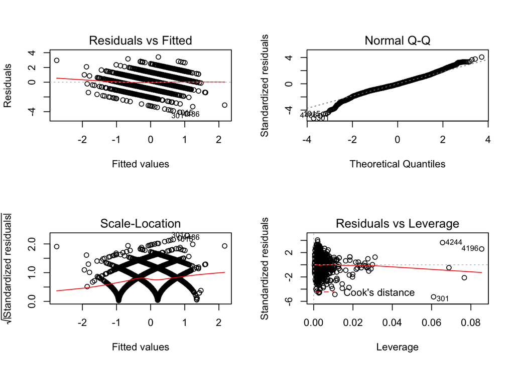

Executando o teste de shapiro no modelo

```
##
##  Shapiro-Wilk normality test
##
## data:  residuals(stepwise)
## W = 0.98764, p-value < 2.2e-16
```

Como o p-value ficou menor que 5 pode-se dizer que temos um modelo de regressão com pouca assertividade.

### Testando o modelo

Executa-se a predição do modelo.

Verificando o erro utilizando a média.

```
## [1] NaN
```

Verificando o erro utilizando media da `qualidade` menos o fit elevado ao quadrado

```
## [1] 0.8408184
```

### Arvore de Regressão

A seguir será executado a árvore de regressão para comparar com a regressão linear. A árvore de regressão é um método de aprendizado supervisionado utilizado para tarefas de classificação e regressão. A variável target é a quality e as variáveis que utilizaremos para prever o seu valor são: fixedacidity, volatileacidity, citricacid, residualsugar, chlorides, freesulfurdioxide, totalsulfurdioxide, density, pH,sulphates,alcohol.

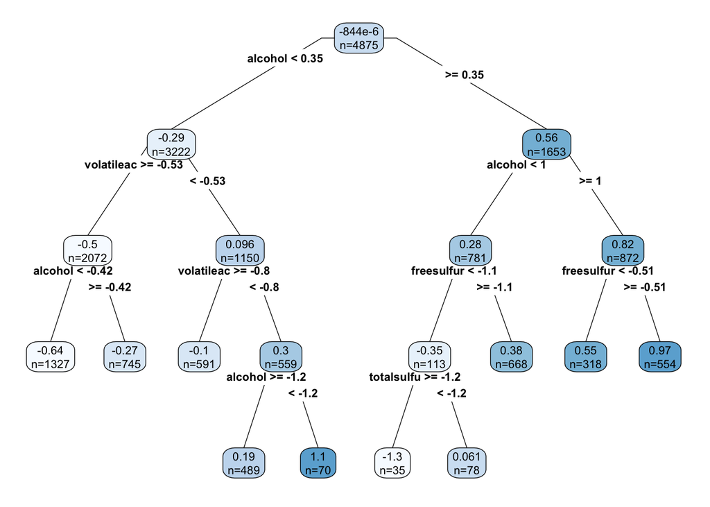

### Testando a árvore de regressão

Erro utilziando o modelo de árvore de regressão

```
## [1] 0.8418957
```

Erro utilizando média

```
## [1] 1.005008
```

E para árvore de regressão pode-se dizer que a quantide de alcool é fundamental para a qualidade do vinho seguindo de ácido volátil.

### Classificando dos Vinhos em Bom ou Ruim considerando a variável Qualidade

Adicionando a coluna de classificação dos vinhos

Executando o modelo com todos as variáveis

Resultado do modelo

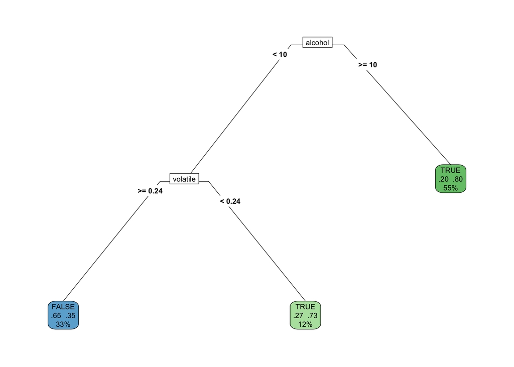

### Testando o modelo

#### Matriz de confusão

```
##        previsto.com.modelo
##         FALSE TRUE
##   FALSE   953  634
##   TRUE    521 2337
```

Calculando a diagonal da matriz

```
## [1] 0.7401575
```

Executando o algoritmo para base de testes

### Clusterizando os Vinhos

Como técnica não supervisionada, vamos testar se o algoritmo de clusterização será adequado para agrupar dois conjunto de vinhos, categorizando-os como vinhos bons e vinhos ruins. ****A variável ‘quality’, que identifica a nota do vinho, será a variável utilizada para correlacionar com as demais variáveis para identificar se existe algum agrupamento entre os vinhos.

De acordo com Luis Costa de Oliveira, Sara Oliveira, Maria Eugenia em seu artigo ‘Avaliação das características físico-químicas e colorimétricas de vinhos finos de duas principais regiões vinícolas do Brasil’, a cor não é uma característica físico-química. ***Portanto foram removidas as colunas de qualidade e tipo de vinho.

```
##   fixedacidity volatileacidity citricacid residualsugar   chlorides
## 1   -0.4746151    -0.605370106  0.2158495     0.4782631 -0.71456718
## 2   -0.3974804     0.002028714  0.7663668    -0.8127137 -0.42912693
## 3    2.6107720    -0.180190932  1.1792548    -0.6857324  0.19884162
## 4   -1.4002313    -0.969809397 -0.5411118    -0.1354800 -0.42912693
## 5   -0.3974804    -0.240930814  0.8351814     2.8168360  0.02757747
## 6   -0.3203458     0.973866825 -1.4357025    -0.8338773  0.54136993
##   freesulfurdioxide totalsulfurdioxide     density          pH
## 1        0.30844314         0.34067222 -0.30186180 -0.17725818
## 2       -0.08593639        -0.03086548 -1.53935241  0.07151784
## 3       -0.70567566        -1.34009358  0.98296453 -0.48822820
## 4       -0.02959646        -0.04855776 -0.08208887  1.25320393
## 5        1.94230121         1.91528439  1.64566442 -0.67481022
## 6       -0.81835553        -1.18086314  0.25602332  0.88003990
##      sulphates     alcohol
## 1 -1.083749410  0.01138345
## 2 -0.613337871  1.73899706
## 3 -0.142926332 -0.56448775
## 4 -0.882144464 -0.89355701
## 5 -0.008523035 -1.14035895
## 6  1.738719824 -0.81128969
```

Utilizando o K-means para descobrir a quantidade ideal de clusters dentro de 10 iterações.

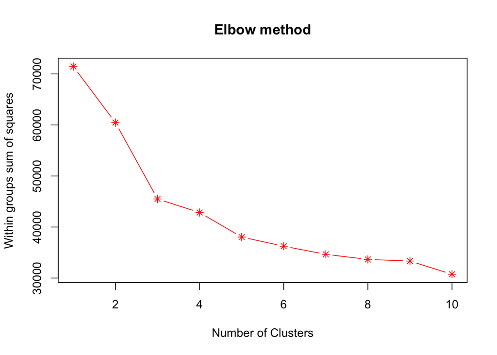

Com base na plotagem, podemos determinar que, após o cluster 3, não vemos uma grande queda na soma das distâncias quadradas dentro de cada cluster, portanto, podemos considerar o valor de K como 3 e prosseguir com o agrupamento

### K-Means Segmentation

```
## K-means clustering with 3 clusters of sizes 1883, 1591, 3023
##
## Cluster means:
##   fixedacidity volatileacidity   citricacid residualsugar   chlorides
## 1   -0.1863534      -0.3499433  0.274175657     1.2178636 -0.09320787
## 2    0.8805505       1.1824096 -0.321908360    -0.6079686  0.94104010
## 3   -0.3473544      -0.4043237 -0.001361747    -0.4386236 -0.43720952
##   freesulfurdioxide totalsulfurdioxide    density          pH  sulphates
## 1        0.84992585         0.95957757  0.7706092 -0.38937177 -0.2572726
## 2       -0.83604364        -1.20558339  0.7193603  0.53721060  0.8437257
## 3       -0.08940289         0.03678419 -0.8586038 -0.04019683 -0.2837986
##      alcohol
## 1 -0.7762507
## 2 -0.1404827
## 3  0.5574555
```

[output cut: 880 more lines]

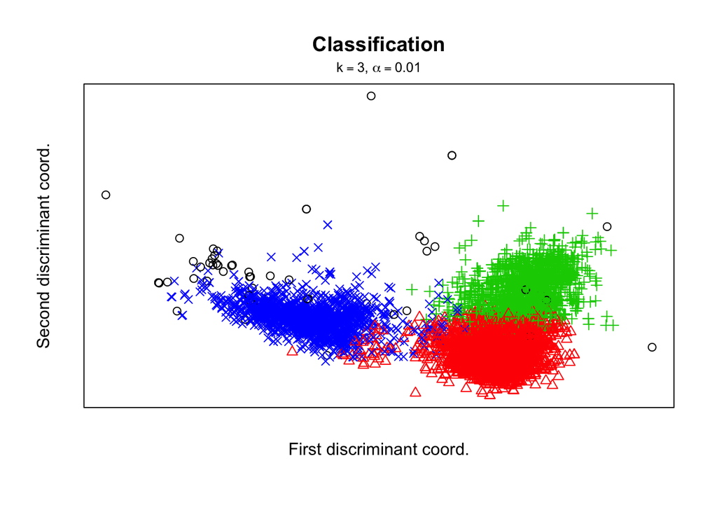

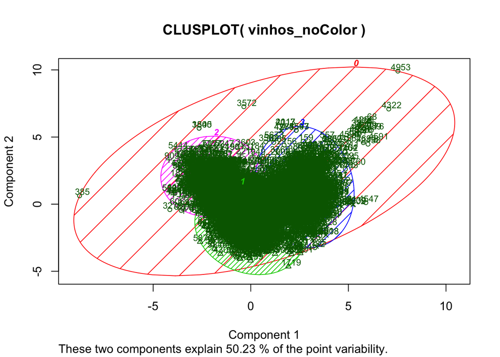